# Risk Factor Analysis

## Outcome Variable

**Outcome Variable:** stunted

## Predictor Variables

**Intervention Variable:** predfeed6

**Adjustment Set:**

- arm
- sex
- month
- brthmon
- W_mage
- meducyrs
- feducyrs
- hhwealth_quart
- hfoodsec
- W_mhtcm
- vagbrth
- W_gagebrth
- W_birthwt
- W_birthlen
- W_nrooms
- W_nchldlt5
- W_parity
- impfloor
- impsan
- safeh20
- delta_W_mage
- delta_meducyrs
- delta_feducyrs
- delta_hhwealth_quart
- delta_hfoodsec
- delta_W_mhtcm
- delta_vagbrth
- delta_W_gagebrth
- delta_W_birthwt
- delta_W_birthlen
- delta_W_nrooms
- delta_W_nchldlt5
- delta_W_parity
- delta_impfloor
- delta_impsan
- delta_safeh20

## Stratifying Variables

The analysis was stratified on these variable(s):

- agecat
- studyid
- country

## Data Summary

| agecat | studyid | country | predfeed6 | stunted | n_cell | n |
| --- | --- | --- | --- | --- | --- | --- |
| Birth | ki0047075b-MAL-ED | BANGLADESH | 0 | 0 | 91 | 231 |
| Birth | ki0047075b-MAL-ED | BANGLADESH | 0 | 1 | 21 | 231 |
| Birth | ki0047075b-MAL-ED | BANGLADESH | 1 | 0 | 101 | 231 |
| Birth | ki0047075b-MAL-ED | BANGLADESH | 1 | 1 | 18 | 231 |
| Birth | ki0047075b-MAL-ED | BRAZIL | 0 | 0 | 134 | 175 |
| Birth | ki0047075b-MAL-ED | BRAZIL | 0 | 1 | 14 | 175 |
| Birth | ki0047075b-MAL-ED | BRAZIL | 1 | 0 | 24 | 175 |
| Birth | ki0047075b-MAL-ED | BRAZIL | 1 | 1 | 3 | 175 |
| Birth | ki0047075b-MAL-ED | INDIA | 0 | 0 | 149 | 190 |
| Birth | ki0047075b-MAL-ED | INDIA | 0 | 1 | 26 | 190 |
| Birth | ki0047075b-MAL-ED | INDIA | 1 | 0 | 10 | 190 |
| Birth | ki0047075b-MAL-ED | INDIA | 1 | 1 | 5 | 190 |
| Birth | ki0047075b-MAL-ED | NEPAL | 0 | 0 | 131 | 170 |
| Birth | ki0047075b-MAL-ED | NEPAL | 0 | 1 | 16 | 170 |
| Birth | ki0047075b-MAL-ED | NEPAL | 1 | 0 | 21 | 170 |
| Birth | ki0047075b-MAL-ED | NEPAL | 1 | 1 | 2 | 170 |
| Birth | ki0047075b-MAL-ED | PERU | 0 | 0 | 132 | 256 |
| Birth | ki0047075b-MAL-ED | PERU | 0 | 1 | 18 | 256 |
| Birth | ki0047075b-MAL-ED | PERU | 1 | 0 | 95 | 256 |
| Birth | ki0047075b-MAL-ED | PERU | 1 | 1 | 11 | 256 |
| Birth | ki0047075b-MAL-ED | SOUTH AFRICA | 0 | 0 | 188 | 211 |
| Birth | ki0047075b-MAL-ED | SOUTH AFRICA | 0 | 1 | 20 | 211 |
| Birth | ki0047075b-MAL-ED | SOUTH AFRICA | 1 | 0 | 1 | 211 |
| Birth | ki0047075b-MAL-ED | SOUTH AFRICA | 1 | 1 | 2 | 211 |
| Birth | ki0047075b-MAL-ED | TANZANIA, UNITED REPUBLIC OF | 0 | 0 | 102 | 119 |
| Birth | ki0047075b-MAL-ED | TANZANIA, UNITED REPUBLIC OF | 0 | 1 | 16 | 119 |
| Birth | ki0047075b-MAL-ED | TANZANIA, UNITED REPUBLIC OF | 1 | 0 | 1 | 119 |
| Birth | ki0047075b-MAL-ED | TANZANIA, UNITED REPUBLIC OF | 1 | 1 | 0 | 119 |
| Birth | ki1000109-EE | PAKISTAN | 0 | 0 | 0 | 4 |
| Birth | ki1000109-EE | PAKISTAN | 0 | 1 | 2 | 4 |

[output cut: 106 more lines]

The following strata were considered:

- agecat: 24 months, studyid: ki0047075b-MAL-ED, country: BANGLADESH
- agecat: 24 months, studyid: ki0047075b-MAL-ED, country: BRAZIL
- agecat: 24 months, studyid: ki0047075b-MAL-ED, country: INDIA
- agecat: 24 months, studyid: ki0047075b-MAL-ED, country: NEPAL
- agecat: 24 months, studyid: ki0047075b-MAL-ED, country: PERU
- agecat: 24 months, studyid: ki0047075b-MAL-ED, country: SOUTH AFRICA
- agecat: 24 months, studyid: ki0047075b-MAL-ED, country: TANZANIA, UNITED REPUBLIC OF
- agecat: 24 months, studyid: ki1113344-GMS-Nepal, country: NEPAL
- agecat: 24 months, studyid: ki1148112-LCNI-5, country: MALAWI
- agecat: 24 months, studyid: kiGH5241-JiVitA-3, country: BANGLADESH
- agecat: 24 months, studyid: kiGH5241-JiVitA-4, country: BANGLADESH
- agecat: 6 months, studyid: ki0047075b-MAL-ED, country: BANGLADESH
- agecat: 6 months, studyid: ki0047075b-MAL-ED, country: BRAZIL
- agecat: 6 months, studyid: ki0047075b-MAL-ED, country: INDIA
- agecat: 6 months, studyid: ki0047075b-MAL-ED, country: NEPAL
- agecat: 6 months, studyid: ki0047075b-MAL-ED, country: PERU
- agecat: 6 months, studyid: ki0047075b-MAL-ED, country: SOUTH AFRICA
- agecat: 6 months, studyid: ki0047075b-MAL-ED, country: TANZANIA, UNITED REPUBLIC OF
- agecat: 6 months, studyid: ki1000109-EE, country: PAKISTAN
- agecat: 6 months, studyid: ki1000304b-SAS-FoodSuppl, country: INDIA
- agecat: 6 months, studyid: ki1113344-GMS-Nepal, country: NEPAL
- agecat: 6 months, studyid: ki1148112-LCNI-5, country: MALAWI
- agecat: 6 months, studyid: kiGH5241-JiVitA-3, country: BANGLADESH
- agecat: 6 months, studyid: kiGH5241-JiVitA-4, country: BANGLADESH
- agecat: Birth, studyid: ki0047075b-MAL-ED, country: BANGLADESH
- agecat: Birth, studyid: ki0047075b-MAL-ED, country: BRAZIL
- agecat: Birth, studyid: ki0047075b-MAL-ED, country: INDIA
- agecat: Birth, studyid: ki0047075b-MAL-ED, country: NEPAL
- agecat: Birth, studyid: ki0047075b-MAL-ED, country: PERU
- agecat: Birth, studyid: ki0047075b-MAL-ED, country: SOUTH AFRICA
- agecat: Birth, studyid: ki0047075b-MAL-ED, country: TANZANIA, UNITED REPUBLIC OF
- agecat: Birth, studyid: ki1000109-EE, country: PAKISTAN
- agecat: Birth, studyid: kiGH5241-JiVitA-3, country: BANGLADESH
- agecat: Birth, studyid: kiGH5241-JiVitA-4, country: BANGLADESH

### Dropped Strata

Some strata were dropped due to rare outcomes:

- agecat: Birth, studyid: ki0047075b-MAL-ED, country: BRAZIL
- agecat: Birth, studyid: ki0047075b-MAL-ED, country: NEPAL
- agecat: Birth, studyid: ki0047075b-MAL-ED, country: SOUTH AFRICA
- agecat: Birth, studyid: ki0047075b-MAL-ED, country: TANZANIA, UNITED REPUBLIC OF
- agecat: Birth, studyid: ki1000109-EE, country: PAKISTAN
- agecat: 6 months, studyid: ki0047075b-MAL-ED, country: BRAZIL
- agecat: 6 months, studyid: ki0047075b-MAL-ED, country: NEPAL
- agecat: 6 months, studyid: ki0047075b-MAL-ED, country: SOUTH AFRICA
- agecat: 6 months, studyid: ki0047075b-MAL-ED, country: TANZANIA, UNITED REPUBLIC OF
- agecat: 6 months, studyid: ki1000304b-SAS-FoodSuppl, country: INDIA
- agecat: 24 months, studyid: ki0047075b-MAL-ED, country: BRAZIL
- agecat: 24 months, studyid: ki0047075b-MAL-ED, country: SOUTH AFRICA
- agecat: 24 months, studyid: ki0047075b-MAL-ED, country: TANZANIA, UNITED REPUBLIC OF

## Methods Detail

We’re interested in the causal parameters $E[Y_a]$ for all values of $a \in \mathcal{A}$. These parameters represent the mean outcome if, possibly contrary to fact, we intervened to set all units to have $A=a$. Under the randomization and positivity assumptions, these are identified by the statistical parameters $\psi_a=E_W[E_{Y|A,W}(Y|A=a,W)]$. In addition, we’re interested in the mean of $Y$, $E[Y]$ under no intervention (the observed mean). We will estimate these parameters by using SuperLearner to fit the relevant likelihood factors – $E_{Y|A,W}(Y|A=a,W)$ and $p(A=a|W)$, and then updating our likelihood fit using a joint TMLE.

For unadjusted analyses ($W=\{\}$), initial likelihoods were estimated using Lrnr_glm to estimate the simple $E(Y|A)$ and Lrnr_mean to estimate $p(A)$. For adjusted analyses, a small library containing Lrnr_glmnet, Lrnr_xgboost, and Lrnr_mean was used.

Having estimated these parameters, we will then use the delta method to estimate relative risks and attributable risks relative to a prespecified baseline level of $A$.

# Results Detail

## Results Plots

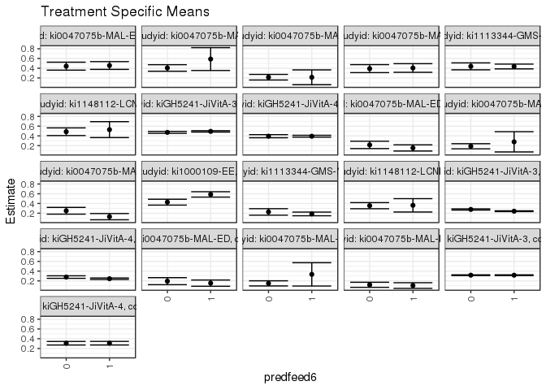

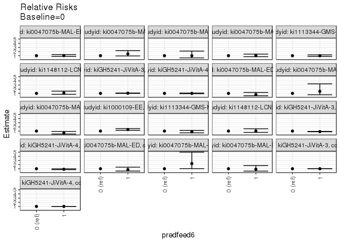

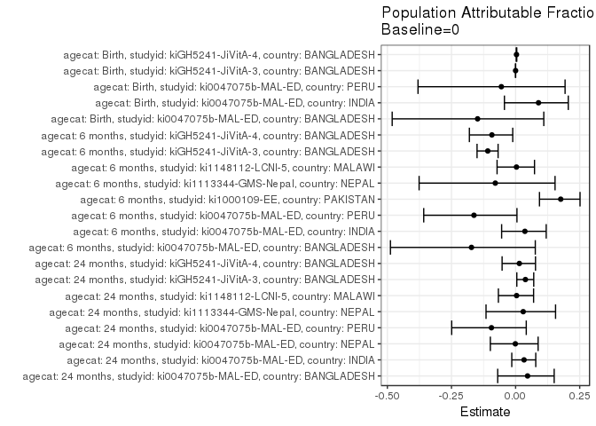

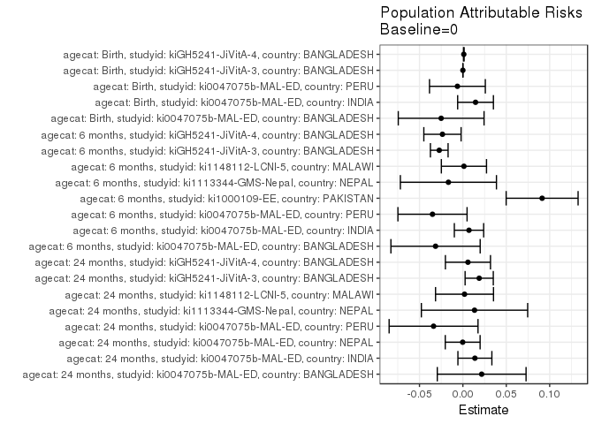

## Results Table

### Parameter: TSM

| agecat | studyid | country | intervention_level | baseline_level | estimate | ci_lower | ci_upper |
| --- | --- | --- | --- | --- | --- | --- | --- |
| Birth | ki0047075b-MAL-ED | BANGLADESH | 0 | NA | 0.1938552 | 0.1220056 | 0.2657047 |
| Birth | ki0047075b-MAL-ED | BANGLADESH | 1 | NA | 0.1536608 | 0.0896905 | 0.2176312 |
| Birth | ki0047075b-MAL-ED | INDIA | 0 | NA | 0.1485714 | 0.0957370 | 0.2014058 |
| Birth | ki0047075b-MAL-ED | INDIA | 1 | NA | 0.3333333 | 0.0941438 | 0.5725228 |
| Birth | ki0047075b-MAL-ED | PERU | 0 | NA | 0.1195737 | 0.0675851 | 0.1715623 |
| Birth | ki0047075b-MAL-ED | PERU | 1 | NA | 0.1043006 | 0.0463228 | 0.1622783 |
| Birth | kiGH5241-JiVitA-3 | BANGLADESH | 0 | NA | 0.3166312 | 0.3090225 | 0.3242399 |
| Birth | kiGH5241-JiVitA-3 | BANGLADESH | 1 | NA | 0.3166210 | 0.3090115 | 0.3242305 |
| Birth | kiGH5241-JiVitA-4 | BANGLADESH | 0 | NA | 0.3079277 | 0.2712467 | 0.3446086 |
| Birth | kiGH5241-JiVitA-4 | BANGLADESH | 1 | NA | 0.3088936 | 0.2721427 | 0.3456446 |
| 6 months | ki0047075b-MAL-ED | BANGLADESH | 0 | NA | 0.2144684 | 0.1392571 | 0.2896796 |
| 6 months | ki0047075b-MAL-ED | BANGLADESH | 1 | NA | 0.1528726 | 0.0892625 | 0.2164827 |
| 6 months | ki0047075b-MAL-ED | INDIA | 0 | NA | 0.1869159 | 0.1345715 | 0.2392603 |
| 6 months | ki0047075b-MAL-ED | INDIA | 1 | NA | 0.2777778 | 0.0704135 | 0.4851421 |
| 6 months | ki0047075b-MAL-ED | PERU | 0 | NA | 0.2506218 | 0.1813925 | 0.3198511 |
| 6 months | ki0047075b-MAL-ED | PERU | 1 | NA | 0.1296597 | 0.0660310 | 0.1932884 |
| 6 months | ki1000109-EE | PAKISTAN | 0 | NA | 0.4275078 | 0.3672992 | 0.4877165 |
| 6 months | ki1000109-EE | PAKISTAN | 1 | NA | 0.5863204 | 0.5312614 | 0.6413794 |
| 6 months | ki1113344-GMS-Nepal | NEPAL | 0 | NA | 0.2272910 | 0.1606942 | 0.2938878 |
| 6 months | ki1113344-GMS-Nepal | NEPAL | 1 | NA | 0.1856747 | 0.1478839 | 0.2234654 |
| 6 months | ki1148112-LCNI-5 | MALAWI | 0 | NA | 0.3553990 | 0.2927797 | 0.4180184 |
| 6 months | ki1148112-LCNI-5 | MALAWI | 1 | NA | 0.3624639 | 0.2253921 | 0.4995358 |
| 6 months | kiGH5241-JiVitA-3 | BANGLADESH | 0 | NA | 0.2780301 | 0.2654994 | 0.2905609 |
| 6 months | kiGH5241-JiVitA-3 | BANGLADESH | 1 | NA | 0.2420496 | 0.2334225 | 0.2506768 |
| 6 months | kiGH5241-JiVitA-4 | BANGLADESH | 0 | NA | 0.2780428 | 0.2516682 | 0.3044173 |
| 6 months | kiGH5241-JiVitA-4 | BANGLADESH | 1 | NA | 0.2440029 | 0.2282953 | 0.2597105 |
| 24 months | ki0047075b-MAL-ED | BANGLADESH | 0 | NA | 0.4424548 | 0.3607642 | 0.5241455 |
| 24 months | ki0047075b-MAL-ED | BANGLADESH | 1 | NA | 0.4562473 | 0.3766654 | 0.5358292 |
| 24 months | ki0047075b-MAL-ED | INDIA | 0 | NA | 0.4057971 | 0.3387537 | 0.4728406 |
| 24 months | ki0047075b-MAL-ED | INDIA | 1 | NA | 0.5882353 | 0.3537610 | 0.8227096 |
| 24 months | ki0047075b-MAL-ED | NEPAL | 0 | NA | 0.2160804 | 0.1587713 | 0.2733895 |
| 24 months | ki0047075b-MAL-ED | NEPAL | 1 | NA | 0.2142857 | 0.0619658 | 0.3666056 |
| 24 months | ki0047075b-MAL-ED | PERU | 0 | NA | 0.3923591 | 0.3105859 | 0.4741323 |
| 24 months | ki0047075b-MAL-ED | PERU | 1 | NA | 0.4050334 | 0.3163466 | 0.4937201 |
| 24 months | ki1113344-GMS-Nepal | NEPAL | 0 | NA | 0.4386608 | 0.3675140 | 0.5098076 |
| 24 months | ki1113344-GMS-Nepal | NEPAL | 1 | NA | 0.4357159 | 0.3863693 | 0.4850626 |
| 24 months | ki1148112-LCNI-5 | MALAWI | 0 | NA | 0.4848733 | 0.4061239 | 0.5636227 |
| 24 months | ki1148112-LCNI-5 | MALAWI | 1 | NA | 0.5282467 | 0.3649356 | 0.6915577 |
| 24 months | kiGH5241-JiVitA-3 | BANGLADESH | 0 | NA | 0.4719466 | 0.4520839 | 0.4918094 |
| 24 months | kiGH5241-JiVitA-3 | BANGLADESH | 1 | NA | 0.4920292 | 0.4781212 | 0.5059371 |
| 24 months | kiGH5241-JiVitA-4 | BANGLADESH | 0 | NA | 0.3933001 | 0.3614901 | 0.4251102 |
| 24 months | kiGH5241-JiVitA-4 | BANGLADESH | 1 | NA | 0.3925775 | 0.3733367 | 0.4118183 |

### Parameter: E(Y)

| agecat | studyid | country | intervention_level | baseline_level | estimate | ci_lower | ci_upper |
| --- | --- | --- | --- | --- | --- | --- | --- |
| Birth | ki0047075b-MAL-ED | BANGLADESH | NA | NA | 0.1688312 | 0.1204189 | 0.2172434 |
| Birth | ki0047075b-MAL-ED | INDIA | NA | NA | 0.1631579 | 0.1104782 | 0.2158376 |
| Birth | ki0047075b-MAL-ED | PERU | NA | NA | 0.1132813 | 0.0743812 | 0.1521813 |
| Birth | kiGH5241-JiVitA-3 | BANGLADESH | NA | NA | 0.3166335 | 0.3090239 | 0.3242430 |
| Birth | kiGH5241-JiVitA-4 | BANGLADESH | NA | NA | 0.3089961 | 0.2722361 | 0.3457561 |
| 6 months | ki0047075b-MAL-ED | BANGLADESH | NA | NA | 0.1829787 | 0.1334386 | 0.2325189 |
| 6 months | ki0047075b-MAL-ED | INDIA | NA | NA | 0.1939655 | 0.1429760 | 0.2449551 |
| 6 months | ki0047075b-MAL-ED | PERU | NA | NA | 0.2156134 | 0.1663773 | 0.2648495 |
| 6 months | ki1000109-EE | PAKISTAN | NA | NA | 0.5188172 | 0.4679751 | 0.5696593 |
| 6 months | ki1113344-GMS-Nepal | NEPAL | NA | NA | 0.2106227 | 0.1763897 | 0.2448557 |
| 6 months | ki1148112-LCNI-5 | MALAWI | NA | NA | 0.3566176 | 0.2995882 | 0.4136471 |
| 6 months | kiGH5241-JiVitA-3 | BANGLADESH | NA | NA | 0.2508093 | 0.2426385 | 0.2589801 |
| 6 months | kiGH5241-JiVitA-4 | BANGLADESH | NA | NA | 0.2545198 | 0.2394884 | 0.2695513 |
| 24 months | ki0047075b-MAL-ED | BANGLADESH | NA | NA | 0.4641148 | 0.3963405 | 0.5318891 |
| 24 months | ki0047075b-MAL-ED | INDIA | NA | NA | 0.4196429 | 0.3548715 | 0.4844143 |
| 24 months | ki0047075b-MAL-ED | NEPAL | NA | NA | 0.2158590 | 0.1622206 | 0.2694975 |
| 24 months | ki0047075b-MAL-ED | PERU | NA | NA | 0.3585859 | 0.2916158 | 0.4255559 |
| 24 months | ki1113344-GMS-Nepal | NEPAL | NA | NA | 0.4520833 | 0.4075129 | 0.4966538 |
| 24 months | ki1148112-LCNI-5 | MALAWI | NA | NA | 0.4867725 | 0.4153250 | 0.5582200 |
| 24 months | kiGH5241-JiVitA-3 | BANGLADESH | NA | NA | 0.4907516 | 0.4775997 | 0.5039035 |
| 24 months | kiGH5241-JiVitA-4 | BANGLADESH | NA | NA | 0.3991375 | 0.3806098 | 0.4176653 |

### Parameter: RR

| agecat | studyid | country | intervention_level | baseline_level | estimate | ci_lower | ci_upper |
| --- | --- | --- | --- | --- | --- | --- | --- |
| Birth | ki0047075b-MAL-ED | BANGLADESH | 0 | 0 | 1.0000000 | 1.0000000 | 1.0000000 |
| Birth | ki0047075b-MAL-ED | BANGLADESH | 1 | 0 | 0.7926580 | 0.4556121 | 1.3790385 |
| Birth | ki0047075b-MAL-ED | INDIA | 0 | 0 | 1.0000000 | 1.0000000 | 1.0000000 |
| Birth | ki0047075b-MAL-ED | INDIA | 1 | 0 | 2.2435897 | 1.0072492 | 4.9974675 |
| Birth | ki0047075b-MAL-ED | PERU | 0 | 0 | 1.0000000 | 1.0000000 | 1.0000000 |
| Birth | ki0047075b-MAL-ED | PERU | 1 | 0 | 0.8722701 | 0.4315012 | 1.7632745 |
| Birth | kiGH5241-JiVitA-3 | BANGLADESH | 0 | 0 | 1.0000000 | 1.0000000 | 1.0000000 |
| Birth | kiGH5241-JiVitA-3 | BANGLADESH | 1 | 0 | 0.9999678 | 0.9999308 | 1.0000048 |
| Birth | kiGH5241-JiVitA-4 | BANGLADESH | 0 | 0 | 1.0000000 | 1.0000000 | 1.0000000 |
| Birth | kiGH5241-JiVitA-4 | BANGLADESH | 1 | 0 | 1.0031370 | 1.0017848 | 1.0044910 |
| 6 months | ki0047075b-MAL-ED | BANGLADESH | 0 | 0 | 1.0000000 | 1.0000000 | 1.0000000 |
| 6 months | ki0047075b-MAL-ED | BANGLADESH | 1 | 0 | 0.7127977 | 0.4141193 | 1.2268939 |
| 6 months | ki0047075b-MAL-ED | INDIA | 0 | 0 | 1.0000000 | 1.0000000 | 1.0000000 |
| 6 months | ki0047075b-MAL-ED | INDIA | 1 | 0 | 1.4861111 | 0.6695514 | 3.2985161 |
| 6 months | ki0047075b-MAL-ED | PERU | 0 | 0 | 1.0000000 | 1.0000000 | 1.0000000 |
| 6 months | ki0047075b-MAL-ED | PERU | 1 | 0 | 0.5173520 | 0.2950285 | 0.9072110 |
| 6 months | ki1000109-EE | PAKISTAN | 0 | 0 | 1.0000000 | 1.0000000 | 1.0000000 |
| 6 months | ki1000109-EE | PAKISTAN | 1 | 0 | 1.3714845 | 1.1826550 | 1.5904636 |
| 6 months | ki1113344-GMS-Nepal | NEPAL | 0 | 0 | 1.0000000 | 1.0000000 | 1.0000000 |
| 6 months | ki1113344-GMS-Nepal | NEPAL | 1 | 0 | 0.8169028 | 0.5721898 | 1.1662743 |
| 6 months | ki1148112-LCNI-5 | MALAWI | 0 | 0 | 1.0000000 | 1.0000000 | 1.0000000 |
| 6 months | ki1148112-LCNI-5 | MALAWI | 1 | 0 | 1.0198788 | 0.6723441 | 1.5470542 |
| 6 months | kiGH5241-JiVitA-3 | BANGLADESH | 0 | 0 | 1.0000000 | 1.0000000 | 1.0000000 |
| 6 months | kiGH5241-JiVitA-3 | BANGLADESH | 1 | 0 | 0.8705877 | 0.8288100 | 0.9144714 |
| 6 months | kiGH5241-JiVitA-4 | BANGLADESH | 0 | 0 | 1.0000000 | 1.0000000 | 1.0000000 |
| 6 months | kiGH5241-JiVitA-4 | BANGLADESH | 1 | 0 | 0.8775731 | 0.7903299 | 0.9744470 |
| 24 months | ki0047075b-MAL-ED | BANGLADESH | 0 | 0 | 1.0000000 | 1.0000000 | 1.0000000 |
| 24 months | ki0047075b-MAL-ED | BANGLADESH | 1 | 0 | 1.0311725 | 0.8330169 | 1.2764647 |
| 24 months | ki0047075b-MAL-ED | INDIA | 0 | 0 | 1.0000000 | 1.0000000 | 1.0000000 |
| 24 months | ki0047075b-MAL-ED | INDIA | 1 | 0 | 1.4495798 | 0.9415618 | 2.2316981 |
| 24 months | ki0047075b-MAL-ED | NEPAL | 0 | 0 | 1.0000000 | 1.0000000 | 1.0000000 |
| 24 months | ki0047075b-MAL-ED | NEPAL | 1 | 0 | 0.9916944 | 0.4643883 | 2.1177486 |
| 24 months | ki0047075b-MAL-ED | PERU | 0 | 0 | 1.0000000 | 1.0000000 | 1.0000000 |
| 24 months | ki0047075b-MAL-ED | PERU | 1 | 0 | 1.0323029 | 0.7701912 | 1.3836164 |
| 24 months | ki1113344-GMS-Nepal | NEPAL | 0 | 0 | 1.0000000 | 1.0000000 | 1.0000000 |
| 24 months | ki1113344-GMS-Nepal | NEPAL | 1 | 0 | 0.9932867 | 0.8185768 | 1.2052852 |
| 24 months | ki1148112-LCNI-5 | MALAWI | 0 | 0 | 1.0000000 | 1.0000000 | 1.0000000 |
| 24 months | ki1148112-LCNI-5 | MALAWI | 1 | 0 | 1.0894531 | 0.7686579 | 1.5441303 |
| 24 months | kiGH5241-JiVitA-3 | BANGLADESH | 0 | 0 | 1.0000000 | 1.0000000 | 1.0000000 |
| 24 months | kiGH5241-JiVitA-3 | BANGLADESH | 1 | 0 | 1.0425525 | 0.9975141 | 1.0896244 |
| 24 months | kiGH5241-JiVitA-4 | BANGLADESH | 0 | 0 | 1.0000000 | 1.0000000 | 1.0000000 |
| 24 months | kiGH5241-JiVitA-4 | BANGLADESH | 1 | 0 | 0.9981626 | 0.9160933 | 1.0875843 |

### Parameter: PAR

| agecat | studyid | country | intervention_level | baseline_level | estimate | ci_lower | ci_upper |
| --- | --- | --- | --- | --- | --- | --- | --- |
| Birth | ki0047075b-MAL-ED | BANGLADESH | 0 | NA | -0.0250240 | -0.0744415 | 0.0243935 |
| Birth | ki0047075b-MAL-ED | INDIA | 0 | NA | 0.0145865 | -0.0060153 | 0.0351882 |
| Birth | ki0047075b-MAL-ED | PERU | 0 | NA | -0.0062925 | -0.0384498 | 0.0258648 |
| Birth | kiGH5241-JiVitA-3 | BANGLADESH | 0 | NA | 0.0000023 | -0.0000066 | 0.0000112 |
| Birth | kiGH5241-JiVitA-4 | BANGLADESH | 0 | NA | 0.0010684 | 0.0007236 | 0.0014133 |
| 6 months | ki0047075b-MAL-ED | BANGLADESH | 0 | NA | -0.0314897 | -0.0829113 | 0.0199320 |
| 6 months | ki0047075b-MAL-ED | INDIA | 0 | NA | 0.0070496 | -0.0098371 | 0.0239364 |
| 6 months | ki0047075b-MAL-ED | PERU | 0 | NA | -0.0350084 | -0.0748430 | 0.0048262 |
| 6 months | ki1000109-EE | PAKISTAN | 0 | NA | 0.0913094 | 0.0498660 | 0.1327527 |
| 6 months | ki1113344-GMS-Nepal | NEPAL | 0 | NA | -0.0166683 | -0.0720245 | 0.0386879 |
| 6 months | ki1148112-LCNI-5 | MALAWI | 0 | NA | 0.0012186 | -0.0247915 | 0.0272287 |
| 6 months | kiGH5241-JiVitA-3 | BANGLADESH | 0 | NA | -0.0272209 | -0.0373993 | -0.0170424 |
| 6 months | kiGH5241-JiVitA-4 | BANGLADESH | 0 | NA | -0.0235229 | -0.0449901 | -0.0020558 |
| 24 months | ki0047075b-MAL-ED | BANGLADESH | 0 | NA | 0.0216600 | -0.0294857 | 0.0728057 |
| 24 months | ki0047075b-MAL-ED | INDIA | 0 | NA | 0.0138458 | -0.0057185 | 0.0334100 |
| 24 months | ki0047075b-MAL-ED | NEPAL | 0 | NA | -0.0002214 | -0.0202957 | 0.0198530 |
| 24 months | ki0047075b-MAL-ED | PERU | 0 | NA | -0.0337732 | -0.0849780 | 0.0174316 |
| 24 months | ki1113344-GMS-Nepal | NEPAL | 0 | NA | 0.0134226 | -0.0478185 | 0.0746636 |
| 24 months | ki1148112-LCNI-5 | MALAWI | 0 | NA | 0.0018992 | -0.0314884 | 0.0352868 |
| 24 months | kiGH5241-JiVitA-3 | BANGLADESH | 0 | NA | 0.0188049 | 0.0025670 | 0.0350429 |
| 24 months | kiGH5241-JiVitA-4 | BANGLADESH | 0 | NA | 0.0058374 | -0.0201372 | 0.0318120 |

### Parameter: PAF

| agecat | studyid | country | intervention_level | baseline_level | estimate | ci_lower | ci_upper |
| --- | --- | --- | --- | --- | --- | --- | --- |
| Birth | ki0047075b-MAL-ED | BANGLADESH | 0 | NA | -0.1482191 | -0.4812793 | 0.1099538 |
| Birth | ki0047075b-MAL-ED | INDIA | 0 | NA | 0.0894009 | -0.0435793 | 0.2054358 |
| Birth | ki0047075b-MAL-ED | PERU | 0 | NA | -0.0555473 | -0.3805412 | 0.1929397 |
| Birth | kiGH5241-JiVitA-3 | BANGLADESH | 0 | NA | 0.0000072 | -0.0000209 | 0.0000353 |
| Birth | kiGH5241-JiVitA-4 | BANGLADESH | 0 | NA | 0.0034577 | 0.0023617 | 0.0045526 |
| 6 months | ki0047075b-MAL-ED | BANGLADESH | 0 | NA | -0.1720947 | -0.4880885 | 0.0767982 |
| 6 months | ki0047075b-MAL-ED | INDIA | 0 | NA | 0.0363448 | -0.0544615 | 0.1193312 |
| 6 months | ki0047075b-MAL-ED | PERU | 0 | NA | -0.1623667 | -0.3582720 | 0.0052830 |
| 6 months | ki1000109-EE | PAKISTAN | 0 | NA | 0.1759953 | 0.0931231 | 0.2512944 |
| 6 months | ki1113344-GMS-Nepal | NEPAL | 0 | NA | -0.0791381 | -0.3762690 | 0.1538434 |
| 6 months | ki1148112-LCNI-5 | MALAWI | 0 | NA | 0.0034171 | -0.0722545 | 0.0737484 |
| 6 months | kiGH5241-JiVitA-3 | BANGLADESH | 0 | NA | -0.1085322 | -0.1503182 | -0.0682641 |
| 6 months | kiGH5241-JiVitA-4 | BANGLADESH | 0 | NA | -0.0924209 | -0.1802159 | -0.0111568 |
| 24 months | ki0047075b-MAL-ED | BANGLADESH | 0 | NA | 0.0466695 | -0.0697979 | 0.1504572 |
| 24 months | ki0047075b-MAL-ED | INDIA | 0 | NA | 0.0329941 | -0.0148853 | 0.0786148 |
| 24 months | ki0047075b-MAL-ED | NEPAL | 0 | NA | -0.0010255 | -0.0984795 | 0.0877826 |
| 24 months | ki0047075b-MAL-ED | PERU | 0 | NA | -0.0941845 | -0.2491638 | 0.0415671 |
| 24 months | ki1113344-GMS-Nepal | NEPAL | 0 | NA | 0.0296904 | -0.1153052 | 0.1558358 |
| 24 months | ki1148112-LCNI-5 | MALAWI | 0 | NA | 0.0039016 | -0.0671051 | 0.0701835 |
| 24 months | kiGH5241-JiVitA-3 | BANGLADESH | 0 | NA | 0.0383186 | 0.0047433 | 0.0707613 |
| 24 months | kiGH5241-JiVitA-4 | BANGLADESH | 0 | NA | 0.0146250 | -0.0526481 | 0.0775988 |